# Cluster Analysis using kmeans

Data Mining

Description for Cluster Analysis using kmeans

Yeongeun Jeon , Jung In Seo  
2023-06-28

> 실습 자료 : 25개 유럽 국가들에 대해 9개의 식품에서 섭취하는 단백질의 양을 조사한 자료(출처 : R을 활용한 다변량 자료분석 방법론)로 총 10개의 변수를 포함한다.

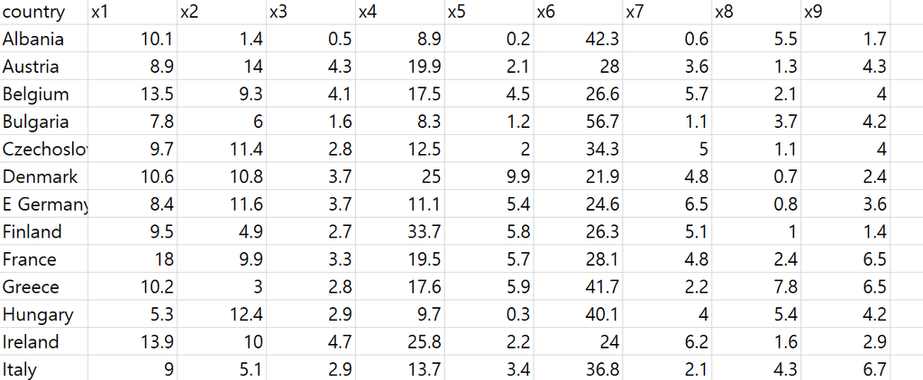

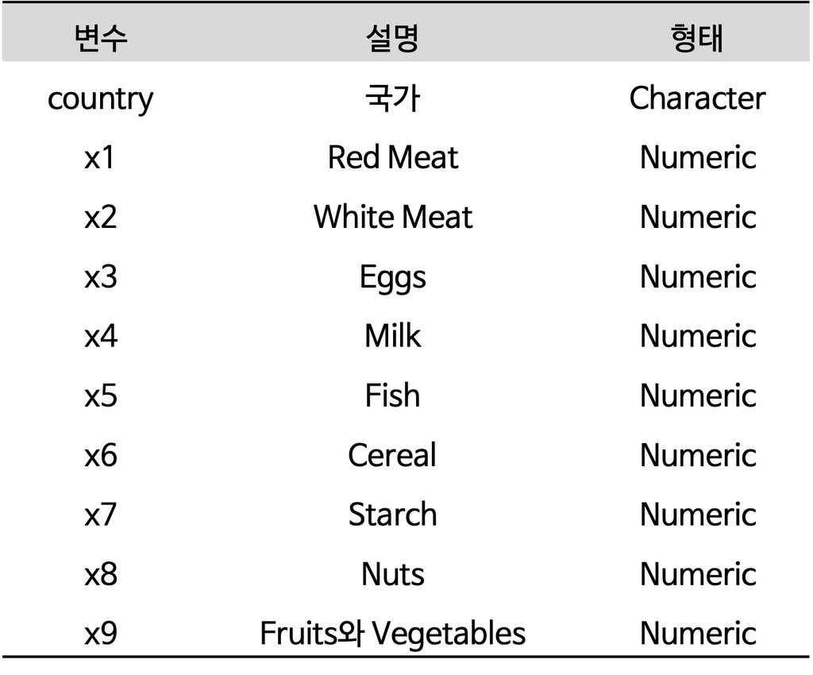

# **1. 데이터 불러오기**

```r
pacman::p_load("data.table",
               "tidyverse",
               "dplyr",
               "caret",
               "GGally",                                       # For ggpairs
               "factoextra",                                   # For fviz_dend, fviz_nbclust
               "NbClust")                                      # For NbClust


protein <- fread(".../protein.csv")                            # 데이터 불러오기

protein %>%
  as_tibble
```

```
# A tibble: 25 × 10
   country          x1    x2    x3    x4    x5    x6    x7    x8    x9
   <chr>         <dbl> <dbl> <dbl> <dbl> <dbl> <dbl> <dbl> <dbl> <dbl>
 1 Albania        10.1   1.4   0.5   8.9   0.2  42.3   0.6   5.5   1.7
 2 Austria         8.9  14     4.3  19.9   2.1  28     3.6   1.3   4.3
 3 Belgium        13.5   9.3   4.1  17.5   4.5  26.6   5.7   2.1   4
 4 Bulgaria        7.8   6     1.6   8.3   1.2  56.7   1.1   3.7   4.2
 5 Czechoslovak…   9.7  11.4   2.8  12.5   2    34.3   5     1.1   4
 6 Denmark        10.6  10.8   3.7  25     9.9  21.9   4.8   0.7   2.4
 7 E Germany       8.4  11.6   3.7  11.1   5.4  24.6   6.5   0.8   3.6
 8 Finland         9.5   4.9   2.7  33.7   5.8  26.3   5.1   1     1.4
 9 France         18     9.9   3.3  19.5   5.7  28.1   4.8   2.4   6.5
10 Greece         10.2   3     2.8  17.6   5.9  41.7   2.2   7.8   6.5
# ℹ 15 more rows
```

# **2. 데이터 전처리 I**

```r
protein.df <- protein %>%
  data.frame %>%                                            # Data Frame 형태로 변환
  select(-country)                                          # 변수 "country" 제거

rownames(protein.df) <- protein$country                     # 행 이름 변경

protein.df %>%
  head()                                                    # 처음 6개 case 확인
```

```
                 x1   x2  x3   x4  x5   x6  x7  x8  x9
Albania        10.1  1.4 0.5  8.9 0.2 42.3 0.6 5.5 1.7
Austria         8.9 14.0 4.3 19.9 2.1 28.0 3.6 1.3 4.3
Belgium        13.5  9.3 4.1 17.5 4.5 26.6 5.7 2.1 4.0
Bulgaria        7.8  6.0 1.6  8.3 1.2 56.7 1.1 3.7 4.2
Czechoslovakia  9.7 11.4 2.8 12.5 2.0 34.3 5.0 1.1 4.0
Denmark        10.6 10.8 3.7 25.0 9.9 21.9 4.8 0.7 2.4
```

# **3. 데이터 탐색**

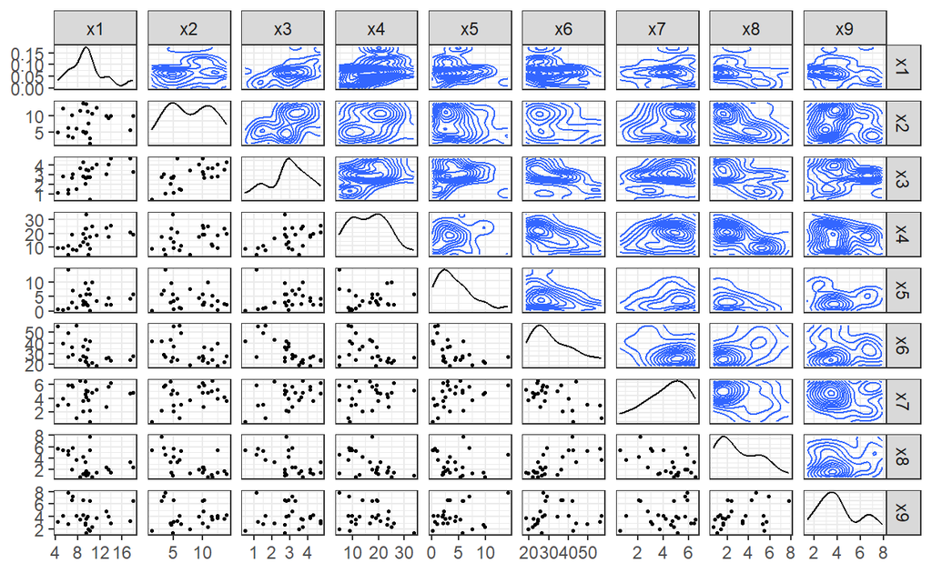

```r
ggpairs(protein.df,
        upper = list(continuous = "density"),
        lower = list(continuous = wrap("points", size = 0.5)),
        diag = list(continuous = "densityDiag")) +
  theme_bw()
```

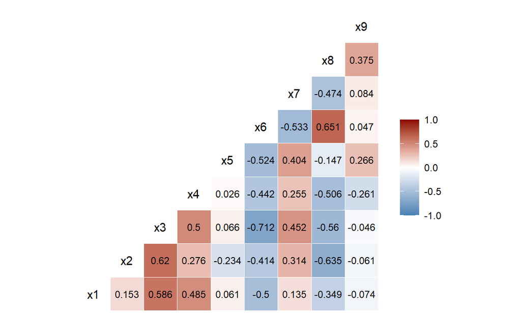

```r
# 상관계수 그래프
ggcorr(protein.df,              # 데이터
       label = TRUE,            # 라벨 명시 여부
       label_round = 3,         # 상관계수 소숫점 이하 자릿수
       label_size = 3,          # 상관계수 글자 크기
       low = "steelblue",       # 상관계수가 음수일 때 색깔
       mid = "white",           # 상관계수가 0에 가까울 때 색깔
       high = "darkred")        # 상관계수가 양수일 때 색깔
```

# **4. 데이터 분할**

```r
# Partition (Training Dataset : Test Dataset = 7:3)
set.seed(200)
ind <- sample(1:nrow(protein.df), 0.7*nrow(protein.df))     # Index를 이용하여 7:3로 분할

protein.trd <- protein.df[ind,]                             # Training Dataset
protein.ted <- protein.df[-ind,]                            # Test Dataset
```

# **5. 데이터 전처리 II**

```r
# Standardization
preProcValues <- preProcess(protein.trd,
                            method = c("center", "scale"))  # Standardization 정의 -> Training Dataset에 대한 평균과 표준편차 계산

protein.trd <- predict(preProcValues, protein.trd)          # Standardization for Training Dataset
protein.ted <- predict(preProcValues, protein.ted)          # Standardization for Test Dataset

glimpse(protein.trd)                                        # 데이터 구조 확인
```

```
Rows: 17
Columns: 9
$ x1 <dbl> 0.18081182, -1.21348962, -0.19945221, -0.16776354, 1.2265…
$ x2 <dbl> 0.8964725, -0.4696659, -0.9554040, -0.8946867, 0.6536035,…
$ x3 <dbl> 0.60866213, -1.46078912, -0.33199753, -0.33199753, 1.5493…
$ x4 <dbl> 0.923106753, -1.136667805, 0.671191879, 2.212318167, 1.04…
$ x5 <dbl> 2.1894978, -1.1166002, 2.1152035, 0.6664639, -0.6708342, …
$ x6 <dbl> -0.8752919, 1.3478740, -0.7870074, -0.5221537, -0.7067487…
$ x7 <dbl> 0.28314770, -0.73972337, 0.16280993, 0.46365436, 1.125512…
$ x8 <dbl> -1.1132630, 1.2269834, -0.6553887, -0.9606382, -0.6553887…
$ x9 <dbl> -0.95800750, -0.69532803, -0.76099790, -1.61470619, -0.62…
```

```r
glimpse(protein.ted)                                        # 데이터 구조 확인
```

```
Rows: 8
Columns: 9
$ x1 <dbl> 0.02236847, -0.35789556, -0.10438620, 2.52577332, -1.4986…
$ x2 <dbl> -1.95723882, 1.86794873, 1.07862431, 0.62324484, 1.382210…
$ x3 <dbl> -2.40144878, 1.17305793, -0.23793156, 0.23239827, -0.1438…
$ x4 <dbl> -1.4626753, 0.1673621, -0.9292085, 0.1080880, -1.3441271,…
$ x5 <dbl> -1.4137775, -0.7079813, -0.7451285, 0.6293167, -1.3766304…
$ x6 <dbl> 0.7619855, -0.3857139, 0.1199159, -0.3776880, 0.5854164, …
$ x7 <dbl> -2.2439455, -0.4388789, 0.4034855, 0.2831477, -0.1982034,…
$ x8 <dbl> 1.3287333, -0.8080135, -0.9097633, -0.2483893, 1.2778583,…
$ x9 <dbl> -1.4176966, 0.2897200, 0.0927104, 1.7344571, 0.2240501, 2…
```

# **6. 계층적 군집분석**

- 계층적 군집분석은 거리가 가까운 군집을 하나씩 묶어가면서 군집을 형성하는 방법이다.
  - 예를 들어, $n$개의 case가 있을 때 거리가 가장 가까운 두 개의 case를 묶어서 하나의 군집을 형성하고, 나머지 $n-2$개의 case는 각각이 하나의 군집을 이루도록 한다.
  - 그리고나서, $n-1$개의 군집 중에서 거리가 가장 가까운 두 개의 군집을 묶어 $n-2$개의 군집을 형성한다.
  - 이와 같은 과정은 최종적으로 $n$개의 case를 모두 묶어 하나의 군집을 형성할 때까지 반복한다.

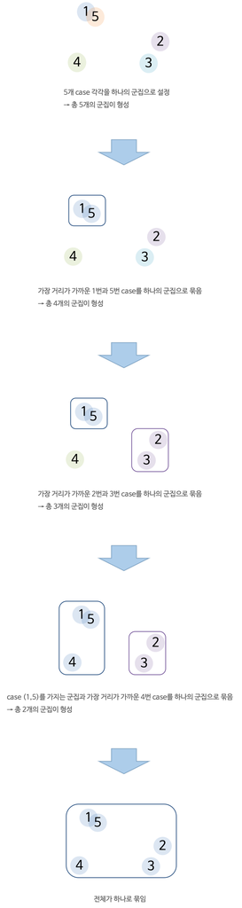

- 계층적 군집분석은 덴드로그램(Dendrogram)을 이용하여 시각적으로 군집 형성 과정을 볼 수 있으며, 이것은 전체 군집들 간의 구조적 관계를 살펴보는데 매우 유용하다.
- 계층적 군집분석은 case의 개수가 비교적 작을 때 유용하다.
  - case의 개수가 많으면 거리행렬을 계산하는 데 매우 많은 시간과 컴퓨터 용량이 필요하므로 적용에 제약이 따른다.
- 계층적 군집분석은 군집 간의 case 이동이 불가능하다는 단점이 있다.

## **6-1. 거리행렬 계산**

- 계층적 군집분석을 수행하기 전에 case 간의 거리를 계산하여 거리행렬을 생성한다.
- 거리행렬을 생성하기 위해 함수 `dist()`를 이용하며, 거리를 계산하는 방법은 옵션 `method`에 지정할 수 있다.
  - 함수 `dist()`의 자세한 옵션은 [여기](https://www.rdocumentation.org/packages/stats/versions/3.6.2/topics/dist)를 참고한다.

```r
protein.X.eucl <- dist(protein.trd,
                       method = "euclidean")                # 유클리드 거리
protein.X.eucl
```

```
             Denmark  Romania   Norway  Finland  Ireland W Germany
Romania     5.899193
Norway      2.190572 5.017093
Finland     2.967850 5.245898 2.336933
Ireland     3.359817 5.698092 4.124494 3.546137
W Germany   2.878437 5.127560 3.800557 4.003049 1.923184
Switzerland 3.738040 4.469147 3.903220 3.935243 2.917500  2.356744
UK          3.867136 5.591679 3.905187 4.132260 2.420596  3.117714
Bulgaria    6.313897 1.931986 5.500563 5.964271 6.225093  5.529229
USSR        4.477896 2.806990 3.501849 3.582533 4.008542  3.961498
Yugoslavia  6.713206 1.004357 5.698797 5.962378 6.560893  5.996864
Italy       5.277250 3.439932 4.454559 5.342612 5.114655  4.328910
Poland      4.399724 4.220409 4.275439 4.655450 4.049754  3.143036
E Germany   3.049396 4.874142 3.609905 4.382604 3.275421  1.990398
Netherlands 3.104750 4.718412 3.958992 3.789881 2.469626  1.324503
Belgium     2.915357 4.886542 3.340291 3.805354 1.828405  1.484545
Greece      5.917754 4.069820 4.853851 5.817338 5.983267  5.564533
            Switzerland       UK Bulgaria     USSR Yugoslavia
Romania
Norway
Finland
Ireland
W Germany
Switzerland
UK             3.060014
Bulgaria       4.441702 5.851565
USSR           3.884788 4.096414 3.822901
Yugoslavia     5.298535 6.426629 2.062393 3.407616
Italy          3.122747 4.448760 2.953685 3.772778   3.819090
Poland         3.160984 4.834137 4.493170 3.288055   4.702444
E Germany      3.737112 4.163853 5.381543 3.551288   5.605003
Netherlands    2.037250 3.815009 5.147099 4.011981   5.573208
Belgium        2.433729 2.074059 5.228214 3.266973   5.724063
Greece         4.319030 4.823118 4.018591 4.352319   4.324015
               Italy   Poland E Germany Netherlands  Belgium
Romania
Norway
Finland
Ireland
W Germany
Switzerland
UK
Bulgaria
USSR
Yugoslavia
Italy
Poland      3.192257
E Germany   4.525418 2.966305
Netherlands 4.210302 2.959231  2.681627
Belgium     3.895649 3.174653  2.239657    2.416333
Greece      2.258867 4.579691  5.805825    5.463629 4.850338
```

```r
protein.X.manh <- dist(protein.trd,
                       method = "manhattan")                # 맨해튼 거리
protein.X.manh
```

```
              Denmark   Romania    Norway   Finland   Ireland
Romania     16.044727
Norway       4.362516 12.653687
Finland      7.235608 13.911994  4.806928
Ireland      7.005266 15.065397  9.247118  9.468623
W Germany    6.311091 14.349831  8.813170  9.834368  5.275630
Switzerland  8.577085 12.171223  9.154543 10.313649  6.016994
UK           9.593477 13.663230  8.600319  9.995946  6.070217
Bulgaria    17.753936  4.687965 14.180745 15.439051 16.643266
USSR        12.013442  7.120222  7.891602  8.669654  9.812398
Yugoslavia  18.709646  2.664919 14.529282 15.787588 17.598976
Italy       14.554763  8.544198 10.811381 12.069687 14.335626
Poland      10.924142 11.435210 10.141752 10.798369  9.205546
E Germany    6.749900 12.877025  9.027131  9.346129  7.631657
Netherlands  6.093145 12.833723  7.316895  9.011894  5.947924
Belgium      7.549654 13.744660  8.862655  9.455895  4.474243
Greece      15.381876 11.152876 11.714511 13.105170 17.020097
            W Germany Switzerland        UK  Bulgaria      USSR
Romania
Norway
Finland
Ireland
W Germany
Switzerland  6.543626
UK           7.184453    8.227596
Bulgaria    14.745643   11.680662 14.533589
USSR         9.705856   10.574401  9.256640  8.515940
Yugoslavia  16.489391   14.190445 15.438486  5.039583  8.864477
Italy       11.546471    8.379349 11.152265  7.639620  7.664063
Poland       7.582684    7.326023 11.798756 11.876059  7.469926
E Germany    5.235333    9.516872 10.027053 13.535516  8.989430
Netherlands  3.547303    4.999723  8.550044 13.360874  9.764597
Belgium      3.617701    5.629898  5.334180 13.877793  8.498996
Greece      14.230942   11.063821 13.168087 11.386135  9.937048
            Yugoslavia     Italy    Poland E Germany Netherlands
Romania
Norway
Finland
Ireland
W Germany
```

[output cut: 13 more lines]

```
Norway
Finland
Ireland
W Germany
Switzerland
UK
Bulgaria
USSR
Yugoslavia
Italy
Poland
E Germany
Netherlands
Belgium
Greece      12.575491
```

```r
protein.X.canb <- dist(protein.trd,
                       method = "canberra")                 # 캔버라 거리
protein.X.canb
```

```
             Denmark  Romania   Norway  Finland  Ireland W Germany
Romania     8.158879
Norway      3.871710 6.733253
Finland     4.767715 7.096226 2.405164
Ireland     3.566184 7.298951 5.111712 5.554244
W Germany   4.438168 8.559232 6.636858 6.534643 4.077482
Switzerland 5.631496 7.384647 6.655474 7.136181 3.826983  5.915036
UK          5.431704 7.121411 5.091535 5.770405 4.848527  6.340807
Bulgaria    9.000000 2.693889 7.429098 7.454773 8.216837  8.644828
USSR        7.836442 4.248394 5.411981 5.563226 6.335265  7.540568
Yugoslavia  8.377778 1.237536 6.804002 7.102698 7.492452  8.534013
Italy       9.000000 4.711358 6.704348 6.751228 8.497561  8.000000
Poland      6.917891 6.900790 6.345653 6.343996 5.459791  5.977593
E Germany   4.243672 7.010160 5.788280 5.086371 4.628132  4.869345
Netherlands 4.715536 7.638203 4.969986 5.904652 4.136367  4.567917
Belgium     5.373320 8.715789 6.976183 6.282932 4.039578  4.848567
Greece      8.053278 5.888016 6.878480 6.435935 8.915575  8.778626
            Switzerland       UK Bulgaria     USSR Yugoslavia
Romania
Norway
Finland
Ireland
W Germany
Switzerland
UK             6.905568
Bulgaria       7.107421 7.301777
USSR           8.258134 6.163877 4.722732
Yugoslavia     7.402525 6.914326 2.909789 4.561988
Italy          7.125692 7.590486 4.318125 4.553765   4.836478
Poland         5.829424 8.169304 6.785597 5.751088   7.259761
E Germany      6.800052 6.180657 7.309833 6.538880   7.081395
Netherlands    4.788712 6.592700 7.840648 7.073731   7.648998
Belgium        5.261781 5.566840 8.198201 7.464957   8.758929
Greece         7.493229 7.883260 6.100786 5.985242   5.742592
               Italy   Poland E Germany Netherlands  Belgium
Romania
Norway
Finland
Ireland
W Germany
Switzerland
UK
Bulgaria
USSR
Yugoslavia
Italy
Poland      5.262433
E Germany   7.429727 6.108030
Netherlands 7.637213 6.225068  4.476133
Belgium     8.504583 6.266166  4.686976    6.323095
Greece      4.140892 6.643087  7.887254    8.885417 7.431991
```

```r
protein.X.mink <- dist(protein.trd,
                       method = "minkowski")                # 민코우스키 거리
protein.X.mink
```

```
             Denmark  Romania   Norway  Finland  Ireland W Germany
Romania     5.899193
Norway      2.190572 5.017093
Finland     2.967850 5.245898 2.336933
Ireland     3.359817 5.698092 4.124494 3.546137
W Germany   2.878437 5.127560 3.800557 4.003049 1.923184
Switzerland 3.738040 4.469147 3.903220 3.935243 2.917500  2.356744
UK          3.867136 5.591679 3.905187 4.132260 2.420596  3.117714
Bulgaria    6.313897 1.931986 5.500563 5.964271 6.225093  5.529229
USSR        4.477896 2.806990 3.501849 3.582533 4.008542  3.961498
Yugoslavia  6.713206 1.004357 5.698797 5.962378 6.560893  5.996864
Italy       5.277250 3.439932 4.454559 5.342612 5.114655  4.328910
Poland      4.399724 4.220409 4.275439 4.655450 4.049754  3.143036
E Germany   3.049396 4.874142 3.609905 4.382604 3.275421  1.990398
Netherlands 3.104750 4.718412 3.958992 3.789881 2.469626  1.324503
Belgium     2.915357 4.886542 3.340291 3.805354 1.828405  1.484545
Greece      5.917754 4.069820 4.853851 5.817338 5.983267  5.564533
            Switzerland       UK Bulgaria     USSR Yugoslavia
Romania
Norway
Finland
Ireland
W Germany
Switzerland
UK             3.060014
Bulgaria       4.441702 5.851565
USSR           3.884788 4.096414 3.822901
Yugoslavia     5.298535 6.426629 2.062393 3.407616
Italy          3.122747 4.448760 2.953685 3.772778   3.819090
Poland         3.160984 4.834137 4.493170 3.288055   4.702444
E Germany      3.737112 4.163853 5.381543 3.551288   5.605003
Netherlands    2.037250 3.815009 5.147099 4.011981   5.573208
Belgium        2.433729 2.074059 5.228214 3.266973   5.724063
Greece         4.319030 4.823118 4.018591 4.352319   4.324015
               Italy   Poland E Germany Netherlands  Belgium
Romania
Norway
Finland
Ireland
W Germany
Switzerland
UK
Bulgaria
USSR
Yugoslavia
Italy
Poland      3.192257
E Germany   4.525418 2.966305
Netherlands 4.210302 2.959231  2.681627
Belgium     3.895649 3.174653  2.239657    2.416333
Greece      2.258867 4.579691  5.805825    5.463629 4.850338
```

`Caution!` 모든 거리행렬을 이용하여 분석을 수행하면 시간이 오래 걸리기 때문에 본 예제에서는 유클리드 거리에 기반한 거리행렬만 이용한다.

## **6-2. 계층적 군집분석**

- 계층적 군집분석은 함수 `hclust()`를 이용하여 수행할 수 있으며, 옵션 `method`에 군집 간 거리를 정의하는 방법을 지정할 수 있다.
  - `"single"` : 최단 연결법
    - 두 군집에 속한 case들의 최단 거리를 군집 간 거리로 정의
  - `"complete"` : 최장 연결법
    - 두 군집에 속한 case들의 최장 거리를 군집 간 거리로 정의
  - `"average"` : 평균 연결법
    - 두 군집에 속한 모든 case 간의 거리 평균을 군집 간 거리로 정의
  - `"ward.D"` : Ward의 방법
    - 군집 내 제곱합과 군집 간 제곱합을 고려
  - `"mcquitty"` : McQuitty의 평균 연결법
  - `"centroid"` : 중심 연결법
  - `"median"` : 중위수 연결법

`Caution!` 옵션 `method`에 지정한 방법에 따라 군집 형성의 결과가 다르다.

```r
protein.X.sing <- hclust(protein.X.eucl,                     # 유클리드 거리에 기반한 거리행렬
                         method = "single")                  # 최단 연결법
protein.X.sing
```

```
Call:
hclust(d = protein.X.eucl, method = "single")

Cluster method   : single
Distance         : euclidean
Number of objects: 17
```

```r
protein.X.comp <- hclust(protein.X.eucl,                     # 유클리드 거리에 기반한 거리행렬
                         method = "complete")                # 최장 연결법
protein.X.comp
```

```
Call:
hclust(d = protein.X.eucl, method = "complete")

Cluster method   : complete
Distance         : euclidean
Number of objects: 17
```

```r
protein.X.aver <- hclust(protein.X.eucl,                     # 유클리드 거리에 기반한 거리행렬
                         method = "average")                 # 평균 연결법
protein.X.aver
```

```
Call:
hclust(d = protein.X.eucl, method = "average")

Cluster method   : average
Distance         : euclidean
Number of objects: 17
```

```r
protein.X.ward <- hclust(protein.X.eucl,                     # 유클리드 거리에 기반한 거리행렬
                           method = "ward.D")                # Ward 방법
protein.X.ward
```

```
Call:
hclust(d = protein.X.eucl, method = "ward.D")

Cluster method   : ward.D
Distance         : euclidean
Number of objects: 17
```

`Caution!` 함수 `cutree()`는 case별 군집 번호를 생성하는 함수이다. 옵션 `k`에 형성하고자 하는 군집 개수를 입력하면 계층적 군집분석의 결과를 이용하여 각 case의 군집 번호를 출력해준다.

```r
# Training Dataset의 case별 군집 번호 생성
hcluster <- cutree(protein.X.ward,                          # Ward 방법을 이용한 계층적 군집분석
                   k = 3)                                   # 형성하고자 하는 군집 개수
hcluster
```

```
    Denmark     Romania      Norway     Finland     Ireland
          1           2           1           1           3
  W Germany Switzerland          UK    Bulgaria        USSR
          3           3           3           2           3
 Yugoslavia       Italy      Poland   E Germany Netherlands
          2           2           3           3           3
    Belgium      Greece
          3           2
```

```r
# Training Dataset과 군집 번호 결합
protein.X.hclust <- data.frame(protein.trd, hcluster)
protein.X.hclust
```

```
                     x1         x2          x3           x4
Denmark      0.18081182  0.8964725  0.60866213  0.923106753
Romania     -1.21348962 -0.4696659 -1.46078912 -1.136667805
Norway      -0.19945221 -0.9554040 -0.33199753  0.671191879
Finland     -0.16776354 -0.8946867 -0.33199753  2.212318167
Ireland      1.22653789  0.6536035  1.54932180  1.041654929
W Germany    0.43432117  1.4125693  0.98492600  0.004358389
Switzerland  0.97302854  0.6839621  0.04426634  0.745284489
UK           2.33564131 -0.6518177  1.54932180  0.271091785
Bulgaria    -0.70647091 -0.5607418 -1.36672316 -1.551586421
USSR        -0.23114088 -0.9857626 -0.89639332 -0.321649095
Yugoslavia  -1.78388566 -0.8643281 -1.74298702 -1.373764157
Italy       -0.32620689 -0.8339695 -0.14386560 -0.751386233
Poland      -0.99166894  0.7143207 -0.33199753  0.078450999
E Germany   -0.51633890  1.1393416  0.60866213 -1.136667805
Netherlands -0.16776354  1.7465142  0.51459617  0.686010401
Belgium      1.09978322  0.4410931  0.98492600 -0.188282397
Greece       0.05405714 -1.4715007 -0.23793156 -0.173463875
                    x5         x6          x7         x8          x9
Denmark      2.1894978 -0.8752919  0.28314770 -1.1132630 -0.95800750
Romania     -1.1166002  1.3478740 -0.73972337  1.2269834 -0.69532803
Norway       2.1152035 -0.7870074  0.16280993 -0.6553887 -0.76099790
Finland      0.6664639 -0.5221537  0.46365436 -0.9606382 -1.61470619
Ireland     -0.6708342 -0.7067487  1.12551212 -0.6553887 -0.62965816
W Germany   -0.2250681 -1.1401456  0.52382325 -0.7062636 -0.03862933
Switzerland -0.6336870 -0.5783347 -0.92023003 -0.2483893  0.68373923
UK           0.1092564 -0.6826711  0.22297882  0.2603599 -0.36697868
Bulgaria    -1.0423058  1.9177108 -1.94310111  0.4129847  0.22405014
USSR        -0.3736568  0.8663218  1.24584989  0.2603599 -0.62965816
Yugoslavia  -1.2651889  1.8535038 -0.79989226  1.4304831 -0.43264855
Italy       -0.2250681  0.3205627 -1.34141224  0.7182342  1.86579687
Poland      -0.3736568  0.2643816  0.94500546 -0.4518890  1.80012700
E Germany    0.5178752 -0.6585934  1.30601878 -1.0623881 -0.16996907
Netherlands -0.5593927 -0.8351626 -0.07786562 -0.5536389 -0.10429920
Belgium      0.1835507 -0.4980760  0.82466768 -0.4010141  0.09271040
Greece       0.7036111  0.7138303 -1.28124336  2.4988565  1.73445713
            hcluster
Denmark            1
Romania            2
Norway             1
Finland            1
Ireland            3
W Germany          3
Switzerland        3
UK                 3
Bulgaria           2
USSR               3
Yugoslavia         2
Italy              2
Poland             3
E Germany          3
Netherlands        3
Belgium            3
Greece             2
```

## **6-3. 덴드로그램**

- 계층적 군집분석의 장점은 덴드로그램을 쉽게 얻을 수 있다는 것이며, 덴드로그램을 통해 case의 군집 형성 과정을 한 눈에 살펴볼 수 있다.

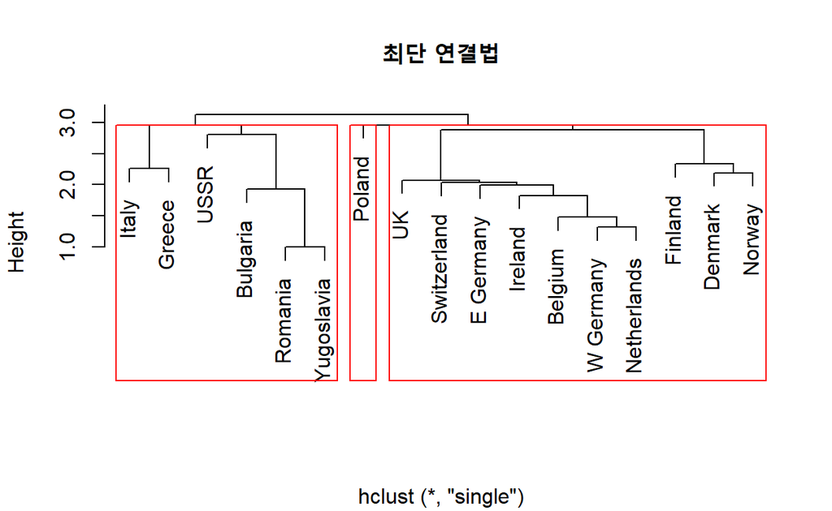

```r
# 최단 연결법을 이용한 계층적 군집분석의 덴드로그램
plot(protein.X.sing,
     main = "최단 연결법",                                 # 제목
     xlab = "")                                            # x축 라벨 이름

# 덴드로그램에 군집 구분 상자 추가
rect.hclust(protein.X.sing,
            k = 3,                                         # 형성하고자 하는 군집 개수
            border = "red")                                # 상자 색깔
```

`Result!` 덴드로그램을 살펴보면, 가장 아래쪽에 있는(=Height가 가장 짧은=군집 간 거리가 가장 짧은) “Romania”와 “Yugoslavia”가 제일 처음으로 묶여 군집을 형성하였다. 그리고, Height가 두 번째로 짧은 “W Germany”와 “Netherlands”가 묶여 군집을 형성하였다. 세 번째로는 군집 (“W Germany”, “Netherlands”)과 “Belgium”이 묶여 군집을 형성했다는 것을 알 수 있다.

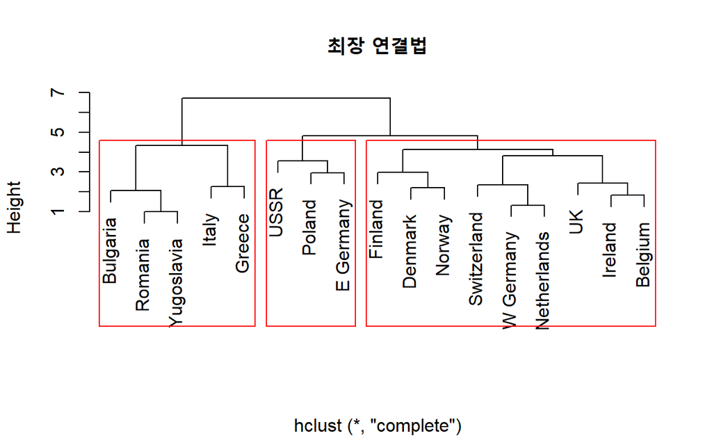

```r
# 최장 연결법을 이용한 계층적 군집분석의 덴드로그램
plot(protein.X.comp,
     main = "최장 연결법",                                 # 제목
     xlab = "")                                            # x축 라벨 이름

# 덴드로그램에 군집 구분 상자 추가
rect.hclust(protein.X.comp,
            k = 3,                                         # 형성하고자 하는 군집 개수
            border = "red")                                # 상자 색깔
```

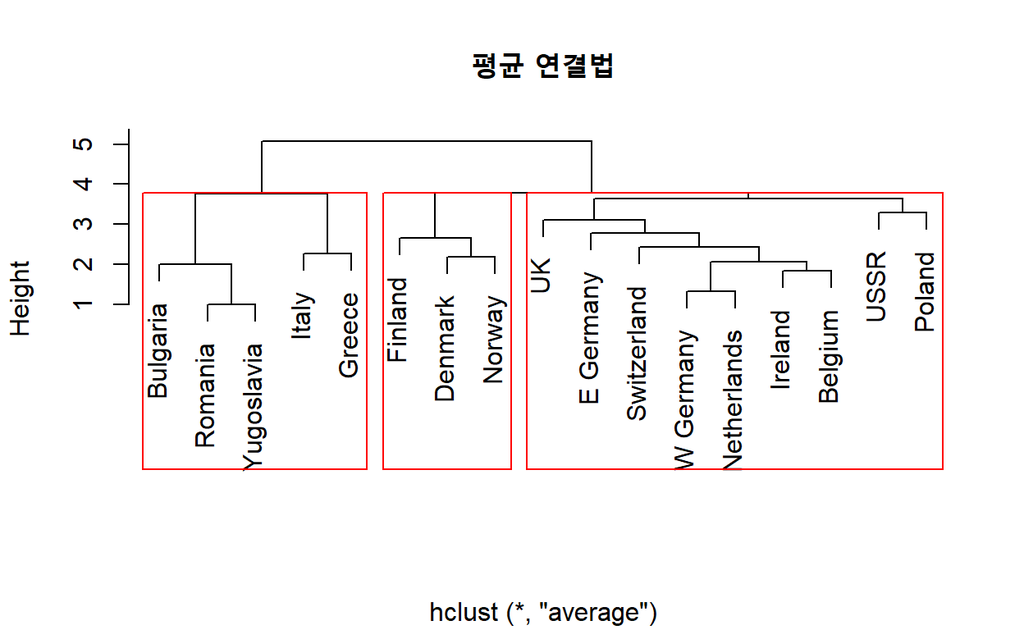

```r
# 평균 연결법을 이용한 계층적 군집분석의 덴드로그램
plot(protein.X.aver,
     main = "평균 연결법",                                 # 제목
     xlab = "")                                            # x축 라벨 이름

# 덴드로그램에 군집 구분 상자 추가
rect.hclust(protein.X.aver,
            k = 3,                                         # 형성하고자 하는 군집 개수
            border = "red")                                # 상자 색깔
```

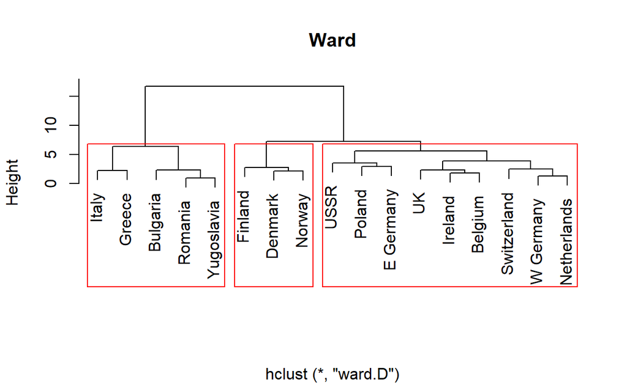

```r
# Ward 방법을 이용한 계층적 군집분석의 덴드로그램
plot(protein.X.ward,
     main = "Ward",                                        # 제목
     xlab = "")                                            # x축 라벨 이름

# 덴드로그램에 군집 구분 상자 추가
rect.hclust(protein.X.ward,
            k = 3,                                         # 형성하고자 하는 군집 개수
            border = "red")                                # 상자 색깔
```

`Caution!` Package `"factoextra"`에서 제공하는 함수 `fviz_dend()`를 이용하면 덴드로그램의 시각화 옵션을 다양하게 변경할 수 있다.

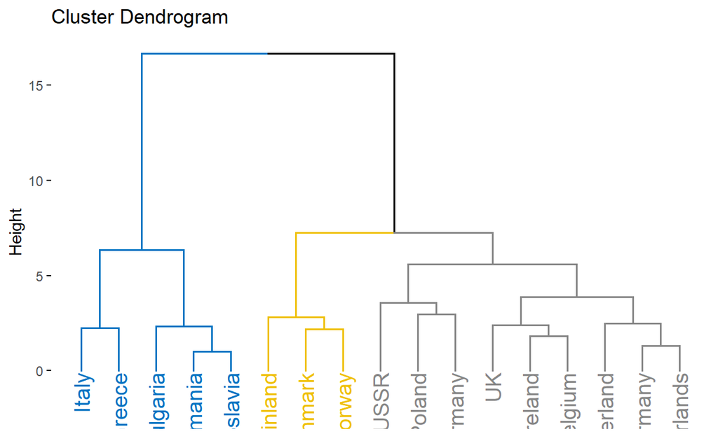

```r
protein.X.ward %>%
  fviz_dend(cex = 1,                                       # 라벨 크기
            k = 3,                                         # 형성하고자 하는 군집 개수
            palette = "jco")                               # 군집 색깔
```

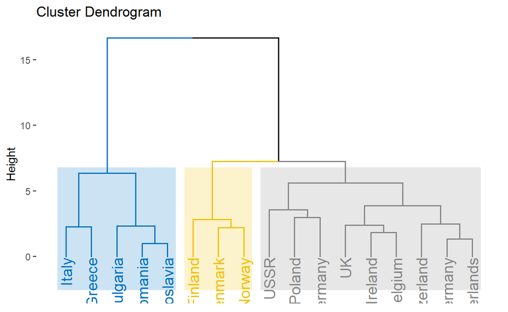

```r
protein.X.ward %>%
  fviz_dend(cex = 1,                                       # 라벨 크기
            k = 3,                                         # 형성하고자 하는 군집 개수
            palette = "jco",                               # 군집 색깔
            # 덴드로그램에 군집 구분 상자 추가
            rect = TRUE,                                   # 상자 표시 여부
            rect_border = "jco",                           # 상자 색깔
            rect_fill = TRUE)                              # 상자 색깔 채우기 여부 / FALSE : 선만 표시
```

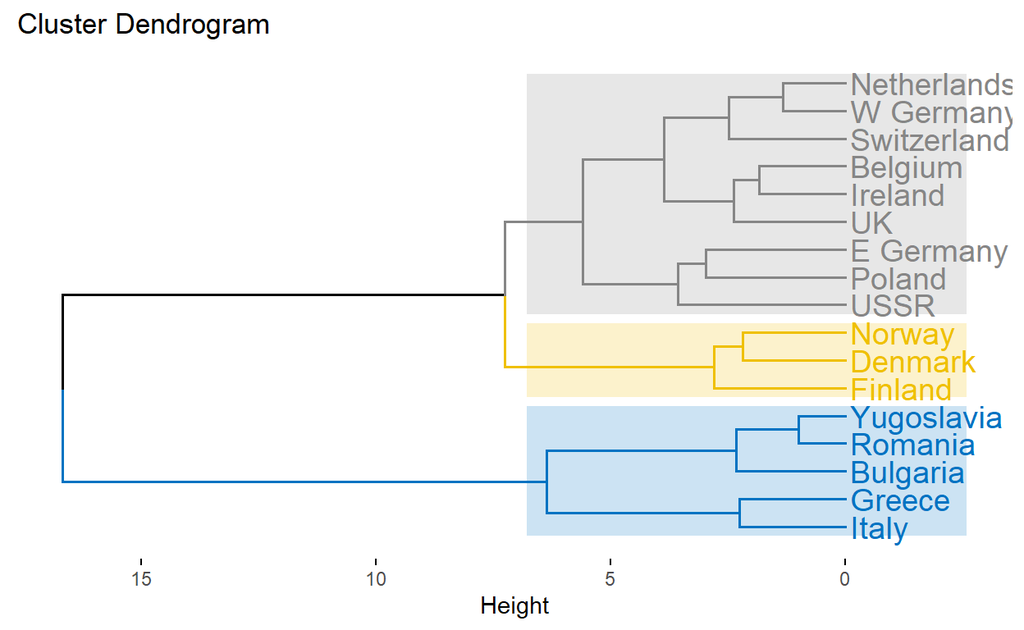

```r
protein.X.ward %>%
  fviz_dend(cex = 1,                                       # 라벨 크기
            k = 3,                                         # 형성하고자 하는 군집 개수
            palette = "jco",                               # 군집 색깔
            # 덴드로그램에 군집 구분 상자 추가
            rect = TRUE,                                   # 상자 표시 여부
            rect_border = "jco",                           # 상자 색깔
            rect_fill = TRUE,
            horiz = TRUE)                                  # 가로로 회전
```

## **6-4. 거리행렬만 주어진 경우**

- Dataset의 예측 변수 값은 주어지지 않았으며, 거리행렬만 알고 있는 경우 계층적 군집분석을 수행하는 절차는 다음과 같다.
  1. 주어진 거리행렬을 함수 `as.dist()`를 이용하여 “dist” 객체로 변환
  2. 함수 `hclust()`를 이용하여 계층적 군집분석 수행

```r
# 거리행렬
exam71 <- c(0, 1, 7, 9, 1, 0, 3, 6, 7, 3, 0, 5, 9, 6, 5, 0)
exam71.matrix <- matrix(exam71, nrow = 4)
exam71.matrix
```

```
     [,1] [,2] [,3] [,4]
[1,]    0    1    7    9
[2,]    1    0    3    6
[3,]    7    3    0    5
[4,]    9    6    5    0
```

```r
exam71.dist <- as.dist(exam71.matrix)                       # "dist" 객체로 변환
exam71.dist
```

```
  1 2 3
2 1
3 7 3
4 9 6 5
```

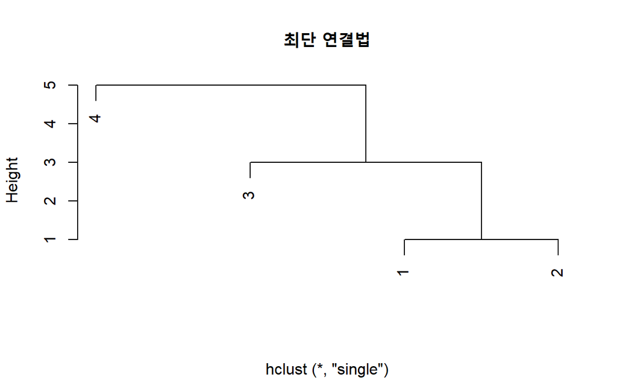

```r
exam71.sing <- hclust(exam71.dist,
                      method = "single")                    # 최단 연결법

# 덴드로그램 Ver.1
plot(exam71.sing,
     main = "최단 연결법",                                  # 제목
     xlab = "")                                             # x축 라벨 이름
```

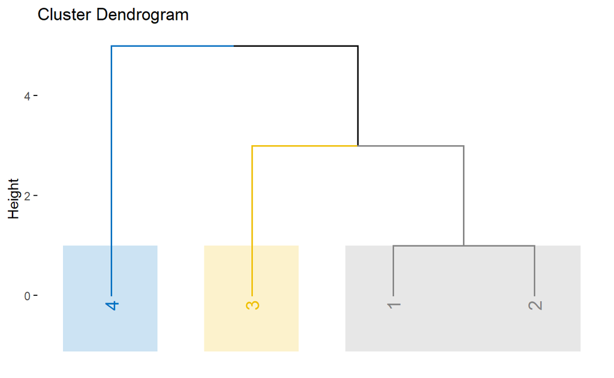

```r
# 덴드로그램 Ver.2
exam71.sing %>%
  fviz_dend(cex = 1,                                       # 라벨 크기
            k = 3,                                         # 형성하고자 하는 군집 개수
            palette = "jco",                               # 군집 색깔
            # 덴드로그램에 군집 구분 상자 추가
            rect = TRUE,                                   # 상자 표시 여부
            rect_border = "jco",                           # 상자 색깔
            rect_fill = TRUE)                              # 상자 색깔 채우기 여부 / FALSE : 선만 표시
```

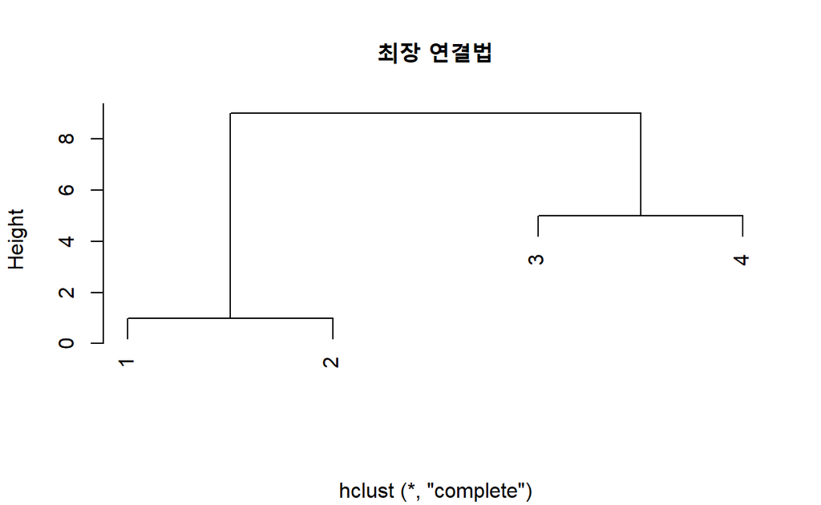

```r
exam71.comp <- hclust(exam71.dist,
                      method = "complete")                  # 최장 연결법

# 덴드로그램 Ver.1
plot(exam71.comp,
     main = "최장 연결법",                                  # 제목
     xlab = "")                                             # x축 라벨 이름
```

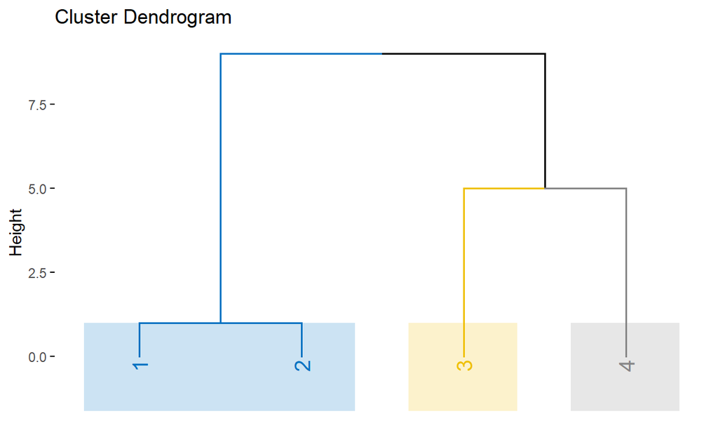

```r
# 덴드로그램 Ver.2
exam71.comp %>%
  fviz_dend(cex = 1,                                       # 라벨 크기
            k = 3,                                         # 형성하고자 하는 군집 개수
            palette = "jco",                               # 군집 색깔
            # 덴드로그램에 군집 구분 상자 추가
            rect = TRUE,                                   # 상자 표시 여부
            rect_border = "jco",                           # 상자 색깔
            rect_fill = TRUE)                              # 상자 색깔 채우기 여부 / FALSE : 선만 표시
```

# **7. 군집 개수 결정**

- 군집 개수를 결정하는 것은 쉽지 않은 문제이며, 여러 가지 지표들을 이용하여 적절한 군집 개수를 찾는 것이 바람직하다.
- 계층적 군집분석은 자료의 계층적 구조에 주된 관심이 있으며, 덴드로그램을 통해 적절한 군집 개수를 결정할 수 있다.
  - 예를 들어, 군집 형성 과정에서 거리의 측도 또는 어떤 지표의 값이 상대적으로 큰 변화를 보일 경우 이를 검토할 필요가 있다.
  - 특히, Ward 방법을 이용하는 경우 군집의 개수에 따른 Error Sum of Squares (ESS)의 증분을 검토하여 급격한 변화가 일어나는 위치에 대응하는 군집 개수를 최적의 군집 개수로 결정하기도 한다.
- 자료의 모분포에 대한 적절한 가정 하에서 통계적 가설검정를 통해 군집의 개수를 알아보는 방법들도 있으나, 이들도 일반적으로 만족할 만한 타당성을 제공하지 않는다.

## **7-1. “fviz_nbclust”**

- Package `"factoextra"`에서 제공하는 함수 `fviz_nbclust()`를 이용하여 군집 개수에 따른 특정 통계량의 변화를 알 수 있다.
  - 옵션 `method`에는 다음과 같은 통계량을 지정할 수 있다.
    1. `"wss"` (군집 내 제곱합, Within-Cluster Sum of Square) : 군집 내 변동의 합계를 의미하며, 해당 값이 작을수록 군집화가 잘 되었음을 나타낸다. 군집의 개수가 증가함에 따라 wss가 작아지게 되는데, `wss가 급격히 감소하다가 감소량이 완만하게 되는 지점`이 최적의 군집 개수에 대한 후보가 될 수 있다.
    2. `"silhouette"` (실루엣 계수, Silhouette Coefficient) : 각 case가 해당 군집에 얼마나 잘 위치하고 있는 지를 측정하는 계수이며, 해당 값이 클 때 군집화가 잘 되었음을 나타낸다. 일반적으로 `평균 실루엣 계수가 가장 큰 지점`의 군집 개수를 최적의 군집 개수로 선택한다.
- 함수 `fviz_nbclust()`의 자세한 옵션은 [여기](https://www.rdocumentation.org/packages/factoextra/versions/1.0.7/topics/fviz_nbclust)를 참고한다.

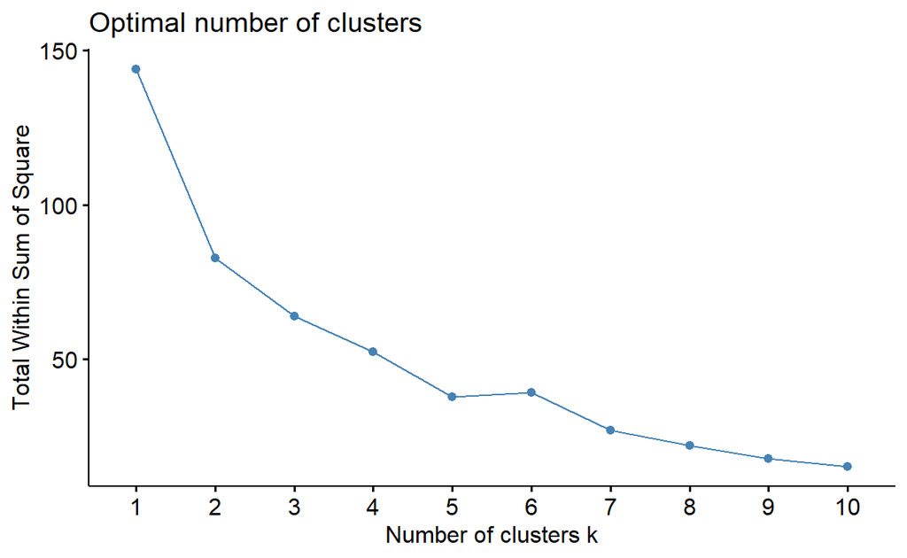

```r
# Method = "wss"
fviz_nbclust(protein.trd,
             kmeans,                                        # 군집분석에 사용할 함수
             method = "wss",                                # 탐색할 통계량
             k.max = 10)                                    # 탐색할 최대 군집 개수
```

`Result!` 군집의 개수가 2-5개일 때, 통계량 wss의 감소량이 완만하게 되기 때문에, 최적의 군집 개수를 2-5개로 선택할 수 있다.

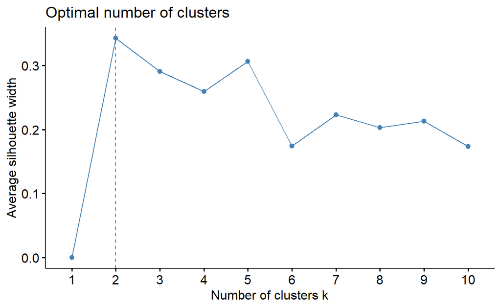

```r
# Method = "silhouette"
fviz_nbclust(protein.trd,
             kmeans,                                        # 군집분석에 사용할 함수
             method = "silhouette",                         # 탐색할 통계량
             k.max = 10)                                    # 탐색할 최대 군집 개수
```

`Result!` 군집의 개수가 2개일 때, 평균 실루엣 계수가 가장 높으므로 최적의 군집 개수를 2개로 선택할 수 있다.

## **7-2. “NbClust”**

- Package `"NbClust"`에서 제공하는 함수 `NbClust()`는 앞에서 설명한 통계량(`"wss"`, `"silhouette"`)을 포함하여 30개의 통계량에 의해 군집의 개수를 결정할 수 있다.
- 함수 `NbClust()`의 자세한 옵션은 [여기](https://www.rdocumentation.org/packages/NbClust/versions/3.0.1/topics/NbClust)를 참고한다.

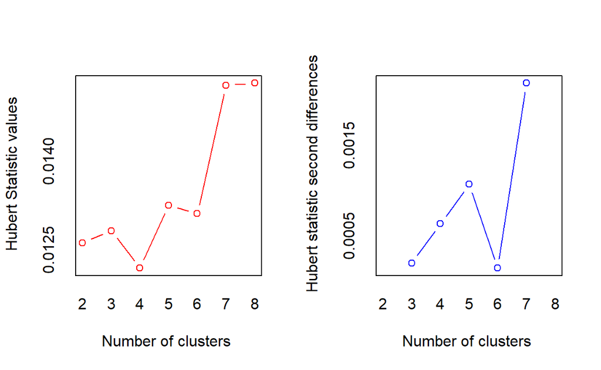

```
*** : The Hubert index is a graphical method of determining the number of clusters.
                In the plot of Hubert index, we seek a significant knee that corresponds to a
                significant increase of the value of the measure i.e the significant peak in Hubert
                index second differences plot.
```

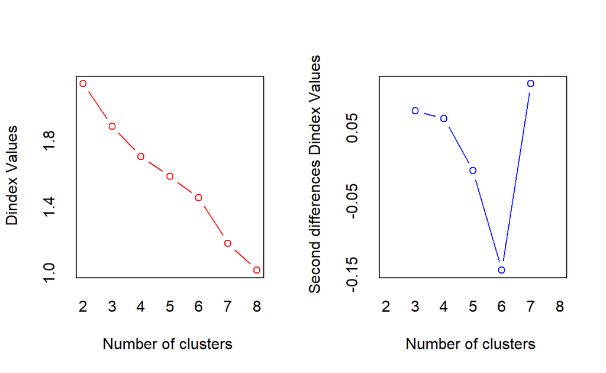

```
*** : The D index is a graphical method of determining the number of clusters.
                In the plot of D index, we seek a significant knee (the significant peak in Dindex
                second differences plot) that corresponds to a significant increase of the value of
                the measure.

* Among all indices:
* 10 proposed 2 as the best number of clusters
* 5 proposed 3 as the best number of clusters
* 3 proposed 4 as the best number of clusters
* 3 proposed 6 as the best number of clusters
* 3 proposed 8 as the best number of clusters

                   ***** Conclusion *****

* According to the majority rule, the best number of clusters is  2
```

```r
nc <- NbClust(data = protein.trd,
              distance = "euclidean",                       # 거리를 계산할 측도
              min.nc = 2,                                   # 탐색할 최소 군집 개수
              max.nc = 8,                                   # 탐색할 최대 군집 개수
              method = "kmeans")                            # 군집분석 방법
```

```r
nc
```

```
$All.index
      KL      CH Hartigan     CCC    Scott      Marriot   TrCovW
2 4.9411 11.1225   3.2331 -0.1756  36.3456 1.421678e+07 146.0938
3 0.6956  7.8181   3.7522 -1.0319  96.3353 9.385189e+05 114.7558
4 3.6704  7.2983   1.4045 -1.3187 137.9082 1.446331e+05  67.7159
5 0.5133  5.9227   1.9786 -2.5078 185.0890 1.408551e+04  62.3318
6 0.3615  5.4222   5.9440 -3.3386 234.5005 1.108751e+03  45.6726
7 2.3162  7.2280   3.0544 -1.8743 284.9642 7.754320e+01  20.5620
8 2.8851  7.6717   1.1819 -1.6783 337.0101 4.741600e+00  13.4502
   TraceW Friedman  Rubin Cindex     DB Silhouette   Duda Pseudot2
2 82.6873  30.9509 1.7415 0.5736 1.1046     0.3431 1.1970  -2.1394
3 68.0250  96.6219 2.1169 0.5519 0.8772     0.3295 3.1874  -4.8039
4 53.6468 106.0892 2.6842 0.5500 1.1372     0.2421 3.2865  -1.3914
5 48.4159 173.9386 2.9742 0.5037 1.0525     0.2789 0.8998   0.5569
6 41.5629 402.5724 3.4646 0.5027 1.0461     0.2133 0.2757   7.8820
7 26.9825 602.5454 5.3368 0.5381 0.9193     0.2820 1.6856  -0.4068
8 20.6693 749.7846 6.9669 0.5279 0.7813     0.3445 7.0565   0.0000
    Beale Ratkowsky    Ball Ptbiserial    Frey McClain   Dunn Hubert
2 -0.8894    0.4422 41.3436     0.7062  1.4601  0.6080 0.6460 0.0126
3 -2.7473    0.4135 22.6750     0.6885  1.5743  0.7685 0.6110 0.0128
4 -2.0889    0.3930 13.4117     0.5273 -0.1000  2.1838 0.3411 0.0122
5  0.5351    0.3619  9.6832     0.5768 36.1590  2.2269 0.4603 0.0133
6 11.8328    0.3428  6.9272     0.4746  0.0607  3.3942 0.3433 0.0131
7  0.0000    0.3403  3.8546     0.5152  0.1602  4.2023 0.4515 0.0153
8  0.0000    0.3270  2.5837     0.5034  1.1889  4.9530 0.5005 0.0153
  SDindex Dindex   SDbw
2  1.0165 2.1448 0.6546
3  0.8783 1.8881 0.4867
4  1.0702 1.7046 0.4059
5  1.0276 1.5839 0.3589
6  1.1107 1.4546 0.3400
7  1.0204 1.1810 0.2757
8  0.9360 1.0175 0.1937

$All.CriticalValues
  CritValue_Duda CritValue_PseudoT2 Fvalue_Beale
2         0.4954            13.2414       1.0000
3         0.2098            26.3677       1.0000
4         0.0985            18.3088       1.0000
5         0.3418             9.6280       0.8391
```

[output cut: 15 more lines]

```
Number_clusters     2.0000 3.0000   2.000 2.000      0  3.0000      0
Value_Index         0.7062 1.5743   0.608 0.646      0  0.8783      0
                  SDbw
Number_clusters 8.0000
Value_Index     0.1937

$Best.partition
    Denmark     Romania      Norway     Finland     Ireland
          1           2           1           1           1
  W Germany Switzerland          UK    Bulgaria        USSR
          1           1           1           2           2
 Yugoslavia       Italy      Poland   E Germany Netherlands
          2           2           1           1           1
    Belgium      Greece
          1           2
```

`Caution!` “$All.index”에서는 군집 개수에 따른 각 통계량의 측정값을 볼 수 있으며, “$Best.nc”에서는 각 통계량에 대해 최적의 군집 개수를 보여준다. “$Best.partition”에서는 최적의 군집 개수에 대한 case별 군집 번호를 보여준다.  
`Result!` “$Best.nc”를 살펴보면, 10개의 통계량에서 최적의 군집 개수로 “2”개를 추천하고 있으며, 5개의 통계량에서 최적의 군집 개수를 “3”개로 추천하고 있다. 대다수의 통계량이 최적의 군집 개수로 “2”개를 추천하고 있으며, 이를 기반으로 나눠진 각 case의 군집 번호는 “$Best.partition”에서 볼 수 있다.

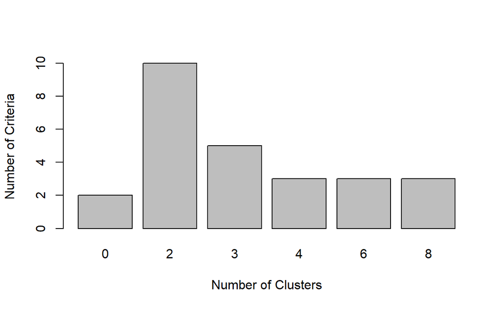

```r
# 여러 통계량의 최적의 군집 개수에 대한 막대 그래프
barplot(table(nc$Best.n[1,]),                               # 군집 개수에 대한 도수분포표
        xlab = "Number of Clusters",
        ylab = "Number of Criteria")
```

`Caution!` 옵션 `index`에 특정 통계량의 이름을 지정하면, 해당 통계량에 대한 결과를 자세히 볼 수 있다.

```r
# Cubic Clustering Criterion 통계량에 대한 최적의 군집 개수
NbClust(data = protein.trd,
        distance = "euclidean",                             # 거리를 계산할 측도
        min.nc = 2,                                         # 탐색할 최소 군집 개수
        max.nc = 8,                                         # 탐색할 최대 군집 개수
        method = "kmeans",                                  # 군집분석 방법
        index = "ccc")                                      # Cubic Clustering Criterion 통계량
```

```
$All.index
      2       3       4       5       6       7       8
-0.1756 -1.0319 -1.3187 -2.5078 -3.3386 -1.8743 -1.6783

$Best.nc
Number_clusters     Value_Index
         2.0000         -0.1756

$Best.partition
    Denmark     Romania      Norway     Finland     Ireland
          1           2           1           1           1
  W Germany Switzerland          UK    Bulgaria        USSR
          1           1           1           2           2
 Yugoslavia       Italy      Poland   E Germany Netherlands
          2           2           1           1           1
    Belgium      Greece
          1           2
```

# **8. 비계층적 군집분석(k-means)**

> k-means의 장점
- 안정적인 결과를 찾을 때까지 각 반복마다 군집 간에 case 이동이 가능하다.
- 예측 변수가 많은 경우, 다른 군집분석 알고리듬에 비해 수행하는 시간이 적게 걸린다.
- 알고리듬 구현이 매우 간단하다.

> k-means의 단점
- 범주형 예측 변수는 거리 계산을 할 수 없으므로 분석에 사용할 수 없다.
- 군집의 개수를 미리 결정해야 한다.
- 예측 변수들의 scale을 동일하게 설정해야 한다.
- 이상치에 민감하다.
- 초기 중심값 선택에 매우 민감하다.
- 비구형 군집에는 잘 작동하지 않는다.

> k-means를 수행하기 위해 사용할 알고리듬

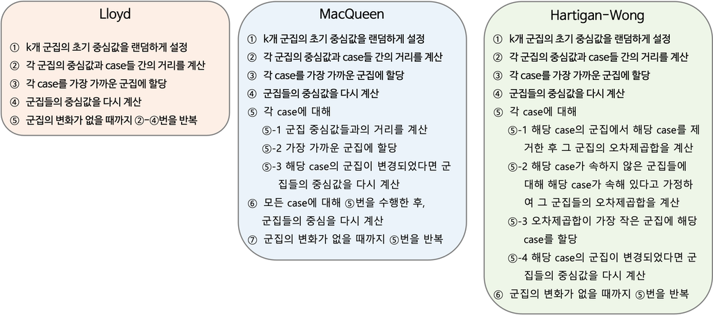

`Caution!` 7. 군집 개수 결정에서 다양한 통계량을 이용하여 결정된 최적의 군집 개수 “2”개를 기반으로 k-means를 수행한다.

```r
# k-means에서 함수 predict()를 사용하기 위해 Package 설치
pacman::p_load("twidlr")                                       # For predict of "kmeans"
# devtools::install_github("drsimonj/twidlr")                  # Install Package "twidlr"
```

## **8-1. Lloyd**

### **8-1-1. 모형 훈련**

```r
set.seed(200)
protein.Lloyd <- kmeans(protein.trd,
                        centers = 2,                         # 형성하고자 하는 군집 개수
                        nstart = 10,                         # 수행 횟수
                        iter.max = 100,                      # 최대 반복 수
                        algorithm = "Lloyd")
protein.Lloyd
```

```
K-means clustering with 2 clusters of sizes 11, 6

Cluster means:
          x1         x2         x3         x4         x5        x6
1  0.3824670  0.4714517  0.5316991  0.4825925  0.3017463 -0.638164
2 -0.7011895 -0.8643281 -0.9747816 -0.8847529 -0.5532015  1.169967
          x7         x8         x9
1  0.4417748 -0.5952638 -0.1878790
2 -0.8099204  1.0913170  0.3444449

Clustering vector:
    Denmark     Romania      Norway     Finland     Ireland
          1           2           1           1           1
  W Germany Switzerland          UK    Bulgaria        USSR
          1           1           1           2           2
 Yugoslavia       Italy      Poland   E Germany Netherlands
          2           2           1           1           1
    Belgium      Greece
          1           2

Within cluster sum of squares by cluster:
[1] 54.69862 27.98864
 (between_SS / total_SS =  42.6 %)

Available components:

[1] "cluster"      "centers"      "totss"        "withinss"
[5] "tot.withinss" "betweenss"    "size"         "iter"
[9] "ifault"
```

`Caution!` k-means는 초기 중심값을 랜덤하게 선택하기 때문에 이 과정에서 다양한 결과가 나타날 수 있다. 그래서 `nstart`를 이용하여 수행 횟수를 늘려 최대한 다양한 초기 중심값에 대해 k-means를 수행하고 최적의 결과를 찾을 수 있다.  
`Result!` 각 군집에 속한 case 수는 11, 6이며, “Within cluster sum of squares by cluster”를 살펴보면 42.6%의 변동이 2개의 군집으로 설명되고 있다.

### **8-1-2. 예측**

```r
# Test Dataset에 대한 군집 번호 예측
pred.Lloyd <- predict(protein.Lloyd,
                      protein.ted)
pred.Lloyd %>%
  as_tibble
```

```
# A tibble: 8 × 1
  value
  <int>
1     2
2     1
3     1
4     1
5     2
6     2
7     2
8     1
```

```r
# Test Dataset과 예측한 군집 번호 결합
pred.protein.ted <- data.frame(protein.ted, pred.Lloyd) %>%
  mutate(pred.Lloyd = factor(pred.Lloyd))                   # 군집 번호를 범주형으로 변환

pred.protein.ted %>%
  as_tibble
```

```
# A tibble: 8 × 10
       x1      x2      x3     x4     x5     x6     x7     x8      x9
    <dbl>   <dbl>   <dbl>  <dbl>  <dbl>  <dbl>  <dbl>  <dbl>   <dbl>
1  0.0224 -1.96   -2.40   -1.46  -1.41   0.762 -2.24   1.33  -1.42
2 -0.358   1.87    1.17    0.167 -0.708 -0.386 -0.439 -0.808  0.290
3 -0.104   1.08   -0.238  -0.929 -0.745  0.120  0.403 -0.910  0.0927
4  2.53    0.623   0.232   0.108  0.629 -0.378  0.283 -0.248  1.73
5 -1.50    1.38   -0.144  -1.34  -1.38   0.585 -0.198  1.28   0.224
6 -1.21   -1.26   -1.84   -2.06   3.79  -0.466  0.945  0.922  2.65
7 -0.928  -1.35    0.0443 -1.51   1.11  -0.289  0.825  1.53   2.19
8 -0.0410 -0.0143  0.421  -2.09   1.30  -1.07  -0.379 -0.757 -1.22
# ℹ 1 more variable: pred.Lloyd <fct>
```

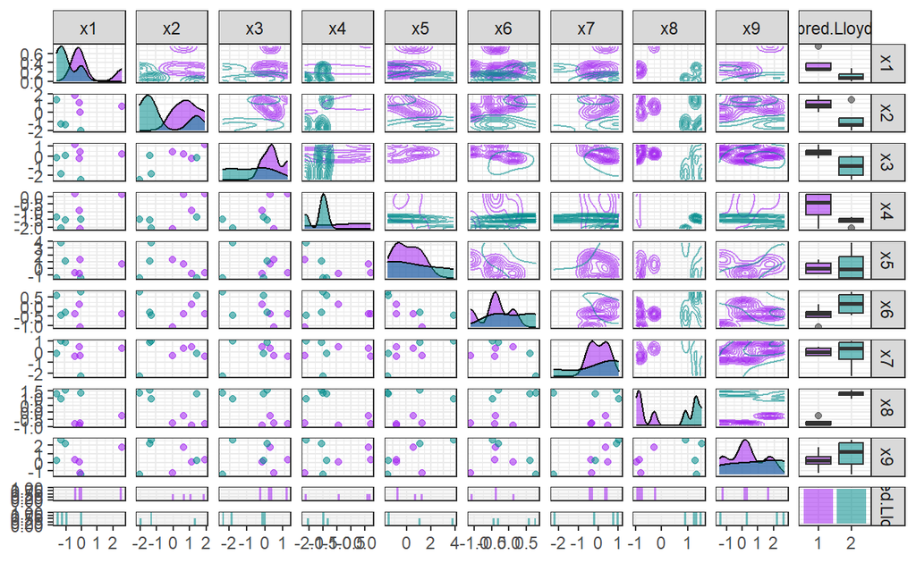

```r
ggpairs(pred.protein.ted,
        aes(colour = pred.Lloyd, alpha = 0.8),              # 군집에 따라 색깔을 다르게 표현
        upper = list(continuous = "density")) +
  scale_colour_manual(values = c("purple","cyan4")) +       # 특정 색깔 지정
  scale_fill_manual(values = c("purple","cyan4")) +         # 특정 색깔 지정
  theme_bw()
```

## **8-2. MacQueen**

### **8-2-1. 모형 훈련**

```r
set.seed(200)
protein.MacQ <- kmeans(protein.trd,
                       centers = 2,                         # 형성하고자 하는 군집 개수
                       nstart = 10,                         # 수행 횟수
                       iter.max = 100,                      # 최대 반복 수
                       algorithm = "MacQueen")
protein.MacQ
```

```
K-means clustering with 2 clusters of sizes 11, 6

Cluster means:
          x1         x2         x3         x4         x5        x6
1  0.3824670  0.4714517  0.5316991  0.4825925  0.3017463 -0.638164
2 -0.7011895 -0.8643281 -0.9747816 -0.8847529 -0.5532015  1.169967
          x7         x8         x9
1  0.4417748 -0.5952638 -0.1878790
2 -0.8099204  1.0913170  0.3444449

Clustering vector:
    Denmark     Romania      Norway     Finland     Ireland
          1           2           1           1           1
  W Germany Switzerland          UK    Bulgaria        USSR
          1           1           1           2           2
 Yugoslavia       Italy      Poland   E Germany Netherlands
          2           2           1           1           1
    Belgium      Greece
          1           2

Within cluster sum of squares by cluster:
[1] 54.69862 27.98864
 (between_SS / total_SS =  42.6 %)

Available components:

[1] "cluster"      "centers"      "totss"        "withinss"
[5] "tot.withinss" "betweenss"    "size"         "iter"
[9] "ifault"
```

`Result!` 각 군집에 속한 case 수는 11, 6이며, “Within cluster sum of squares by cluster”를 살펴보면 42.6%의 변동이 2개의 군집으로 설명되고 있다.

### **8-2-2. 예측**

```r
# Test Dataset에 대한 군집 번호 예측
pred.MacQ <- predict(protein.MacQ,
                     protein.ted)
pred.MacQ %>%
  as_tibble
```

```
# A tibble: 8 × 1
  value
  <int>
1     2
2     1
3     1
4     1
5     2
6     2
7     2
8     1
```

```r
# Test Dataset과 예측한 군집 번호 결합
pred.protein.ted <- data.frame(protein.ted, pred.MacQ) %>%
  mutate(pred.MacQ = factor(pred.MacQ))                     # 군집 번호를 범주형으로 변환

pred.protein.ted %>%
  as_tibble
```

```
# A tibble: 8 × 10
       x1      x2      x3     x4     x5     x6     x7     x8      x9
    <dbl>   <dbl>   <dbl>  <dbl>  <dbl>  <dbl>  <dbl>  <dbl>   <dbl>
1  0.0224 -1.96   -2.40   -1.46  -1.41   0.762 -2.24   1.33  -1.42
2 -0.358   1.87    1.17    0.167 -0.708 -0.386 -0.439 -0.808  0.290
3 -0.104   1.08   -0.238  -0.929 -0.745  0.120  0.403 -0.910  0.0927
4  2.53    0.623   0.232   0.108  0.629 -0.378  0.283 -0.248  1.73
5 -1.50    1.38   -0.144  -1.34  -1.38   0.585 -0.198  1.28   0.224
6 -1.21   -1.26   -1.84   -2.06   3.79  -0.466  0.945  0.922  2.65
7 -0.928  -1.35    0.0443 -1.51   1.11  -0.289  0.825  1.53   2.19
8 -0.0410 -0.0143  0.421  -2.09   1.30  -1.07  -0.379 -0.757 -1.22
# ℹ 1 more variable: pred.MacQ <fct>
```

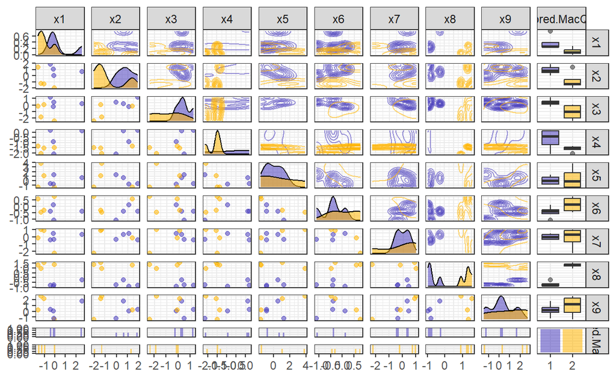

```r
ggpairs(pred.protein.ted,
        aes(colour = pred.MacQ, alpha = 0.8),               # 군집에 따라 색깔을 다르게 표현
        upper = list(continuous = "density")) +
  scale_colour_manual(values = c("#483DBB","#FFB400")) +    # 특정 색깔 지정
  scale_fill_manual(values = c("#483DBB","#FFB400")) +      # 특정 색깔 지정
  theme_bw()
```

## **8-3. Hartigan-Wong**

### **8-3-1. 모형 훈련**

```r
set.seed(200)
protein.HW <- kmeans(protein.trd,
                     centers = 2,                            # 형성하고자 하는 군집 개수
                     nstart = 10,                            # 수행 횟수
                     iter.max = 100,                         # 최대 반복 수
                     algorithm = "Hartigan-Wong")
protein.HW
```

```
K-means clustering with 2 clusters of sizes 11, 6

Cluster means:
          x1         x2         x3         x4         x5        x6
1  0.3824670  0.4714517  0.5316991  0.4825925  0.3017463 -0.638164
2 -0.7011895 -0.8643281 -0.9747816 -0.8847529 -0.5532015  1.169967
          x7         x8         x9
1  0.4417748 -0.5952638 -0.1878790
2 -0.8099204  1.0913170  0.3444449

Clustering vector:
    Denmark     Romania      Norway     Finland     Ireland
          1           2           1           1           1
  W Germany Switzerland          UK    Bulgaria        USSR
          1           1           1           2           2
 Yugoslavia       Italy      Poland   E Germany Netherlands
          2           2           1           1           1
    Belgium      Greece
          1           2

Within cluster sum of squares by cluster:
[1] 54.69862 27.98864
 (between_SS / total_SS =  42.6 %)

Available components:

[1] "cluster"      "centers"      "totss"        "withinss"
[5] "tot.withinss" "betweenss"    "size"         "iter"
[9] "ifault"
```

`Result!` 각 군집에 속한 case 수는 11, 6이며, “Within cluster sum of squares by cluster”를 살펴보면 42.6%의 변동이 2개의 군집으로 설명되고 있다.

### **8-3-2. 예측**

```r
# Test Dataset에 대한 군집 번호 예측
pred.HW <- predict(protein.HW,
                   protein.ted)
pred.HW %>%
  as_tibble
```

```
# A tibble: 8 × 1
  value
  <int>
1     2
2     1
3     1
4     1
5     2
6     2
7     2
8     1
```

```r
# Test Dataset과 예측한 군집 번호 결합
pred.protein.ted <- data.frame(protein.ted, pred.HW) %>%
  mutate(pred.HW = factor(pred.HW))                         # 군집 번호를 범주형으로 변환

pred.protein.ted %>%
  as_tibble
```

```
# A tibble: 8 × 10
       x1      x2      x3     x4     x5     x6     x7     x8      x9
    <dbl>   <dbl>   <dbl>  <dbl>  <dbl>  <dbl>  <dbl>  <dbl>   <dbl>
1  0.0224 -1.96   -2.40   -1.46  -1.41   0.762 -2.24   1.33  -1.42
2 -0.358   1.87    1.17    0.167 -0.708 -0.386 -0.439 -0.808  0.290
3 -0.104   1.08   -0.238  -0.929 -0.745  0.120  0.403 -0.910  0.0927
4  2.53    0.623   0.232   0.108  0.629 -0.378  0.283 -0.248  1.73
5 -1.50    1.38   -0.144  -1.34  -1.38   0.585 -0.198  1.28   0.224
6 -1.21   -1.26   -1.84   -2.06   3.79  -0.466  0.945  0.922  2.65
7 -0.928  -1.35    0.0443 -1.51   1.11  -0.289  0.825  1.53   2.19
8 -0.0410 -0.0143  0.421  -2.09   1.30  -1.07  -0.379 -0.757 -1.22
# ℹ 1 more variable: pred.HW <fct>
```

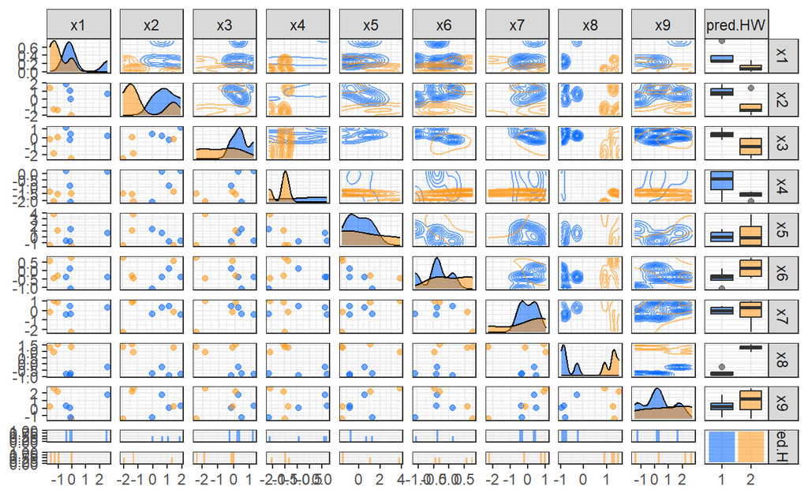

```r
ggpairs(pred.protein.ted,
        aes(colour = pred.HW, alpha = 0.8),                 # 군집에 따라 색깔을 다르게 표현
  upper = list(continuous = "density")) +
  scale_colour_manual(values = c("#0064FF","#FF9614")) +    # 특정 색깔 지정
  scale_fill_manual(values = c("#0064FF","#FF9614")) +      # 특정 색깔 지정
  theme_bw()
```